# Decision Trees/ Machine Learning

Durga Gaddam

August 29, 2016

### Objective:

The objective of the article is to identify the risk of a bank loan. In this article we will develop a credit approval model using C5.0 decision trees.

### Decision Trees:

Decision Trees is one of the most widely used Machine Learning Algorithm. Terminology used in Decision Trees

1. Root node- Beginning of decision tree
2. Decision Nodes- Which help in making choices
3. Branches- potential outcome of a decision
4. Leaf Nodes or Terminal Nodes- Used to terminate the decision.

Decision trees use self-learning process called Recursive Partitioning, or divide and conquer method.

### C5.0 Decision tree algorithm:

#### Entropy:

The algorithm C5.0 uses the technique called entropy, which quantifies the randomness, or disorder within a set of class values

Entropy (S) = $\sum_{i=1}^c p_i log2(p_i)$

#### Infromation Gain

C5.0 algorithm uses Information gain to split for the data set. The data set is divided into two parts. Split1 and Split2. This method is known as Information Gain

Info Gain(F)= Entropy(S1)- Entropy(S2)

#### Step1: Collecting the Data

#### Step2: Exploring and preparing the Data

#### Step3: Training the data model

#### Step4: Evaluating the model performance

#### Step1: Improving model performance

#### Step1: Collecting the Data

The present data is extracted from http://archive.ics.uci.edu/ml/

#### Step2: Exploring and preparing the Data

```r
##library(ggplot2)
credit <- read.csv("credit.csv")
str(credit)
```

```
## 'data.frame':    1000 obs. of  21 variables:
##  $ checking_balance    : Factor w/ 4 levels "< 0 DM","> 200 DM",..: 1 3 4 1 1 4 4 3 4 3 ...
##  $ months_loan_duration: int  6 48 12 42 24 36 24 36 12 30 ...
##  $ credit_history      : Factor w/ 5 levels "critical","delayed",..: 1 5 1 5 2 5 5 5 5 1 ...
##  $ purpose             : Factor w/ 10 levels "business","car (new)",..: 8 8 5 6 2 5 6 3 8 2 ...
##  $ amount              : int  1169 5951 2096 7882 4870 9055 2835 6948 3059 5234 ...
##  $ savings_balance     : Factor w/ 5 levels "< 100 DM","> 1000 DM",..: 5 1 1 1 1 5 4 1 2 1 ...
##  $ employment_length   : Factor w/ 5 levels "> 7 yrs","0 - 1 yrs",..: 1 3 4 4 3 3 1 3 4 5 ...
##  $ installment_rate    : int  4 2 2 2 3 2 3 2 2 4 ...
##  $ personal_status     : Factor w/ 4 levels "divorced male",..: 4 2 4 4 4 4 4 4 1 3 ...
##  $ other_debtors       : Factor w/ 3 levels "co-applicant",..: 3 3 3 2 3 3 3 3 3 3 ...
##  $ residence_history   : int  4 2 3 4 4 4 4 2 4 2 ...
##  $ property            : Factor w/ 4 levels "building society savings",..: 3 3 3 1 4 4 1 2 3 2 ...
##  $ age                 : int  67 22 49 45 53 35 53 35 61 28 ...
##  $ installment_plan    : Factor w/ 3 levels "bank","none",..: 2 2 2 2 2 2 2 2 2 2 ...
##  $ housing             : Factor w/ 3 levels "for free","own",..: 2 2 2 1 1 1 2 3 2 2 ...
##  $ existing_credits    : int  2 1 1 1 2 1 1 1 1 2 ...
##  $ job                 : Factor w/ 4 levels "mangement self-employed",..: 2 2 4 2 2 4 2 1 4 1 ...
##  $ dependents          : int  1 1 2 2 2 2 1 1 1 1 ...
##  $ telephone           : Factor w/ 2 levels "none","yes": 2 1 1 1 1 2 1 2 1 1 ...
##  $ foreign_worker      : Factor w/ 2 levels "no","yes": 2 2 2 2 2 2 2 2 2 2 ...
##  $ default             : int  1 2 1 1 2 1 1 1 1 2 ...
```

```r
table(credit$checking_balance)
```

```
##
##     < 0 DM   > 200 DM 1 - 200 DM    unknown
##        274         63        269        394
```

```r
table(credit$savings_balance)
```

```
##
##      < 100 DM     > 1000 DM  101 - 500 DM 501 - 1000 DM       unknown
##           603            48           103            63           183
```

```r
##Here DM indicates currency of Germany Deutsche Marks(DM)

summary(credit$months_loan_duration)
```

```
##    Min. 1st Qu.  Median    Mean 3rd Qu.    Max.
##     4.0    12.0    18.0    20.9    24.0    72.0
```

```r
summary(credit$amount)
```

```
##    Min. 1st Qu.  Median    Mean 3rd Qu.    Max.
##     250    1366    2320    3271    3972   18420
```

Through this we can observe that the minimum loan duration was 4 and maximum duration was 72

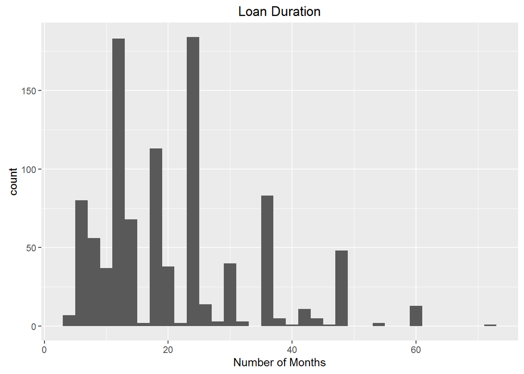

```r
require(ggplot2)
qplot(credit$months_loan_duration, xlab="Number of Months", main = "Loan Duration",geom="histogram", binwidth=2)
```

```r
credit$default <-factor(credit$default, levels=c("1","2"), labels=c("No","Yes"))

table(credit$default)
```

```
##
##  No Yes
## 700 300
```

```r
a <- sample(1000,900)
```

The default vector in the dataset indicates the response of whether the applicant met the agreed payment terms.

To prepare training data and testing data, we need to divide the data randomly

```r
set.seed(12354)
train_sample <- sample(1000,800)

credit_train <- credit[train_sample,]
credit_test <- credit[-train_sample,]

prop.table(table(credit_train$default))
```

```
##
##      No     Yes
## 0.70125 0.29875
```

```r
prop.table(table(credit_test$default))
```

```
##
##    No   Yes
## 0.695 0.305
```

### Step-3 Training the data Model

we need to remove the 21st column from the data model

```r
##install.packages("C50")
##library(C50)
require(C50)
credit_model <- C5.0(credit_train[-21], credit_train$default)

credit_model
```

```
##
## Call:
## C5.0.default(x = credit_train[-21], y = credit_train$default)
##
## Classification Tree
## Number of samples: 800
## Number of predictors: 20
##
## Tree size: 43
##
## Non-standard options: attempt to group attributes
```

```r
summary(credit_model)
```

```
##
## Call:
## C5.0.default(x = credit_train[-21], y = credit_train$default)
##
##
## C5.0 [Release 2.07 GPL Edition]      Tue Aug 30 19:23:22 2016
## -------------------------------
##
## Class specified by attribute `outcome'
##
## Read 800 cases (21 attributes) from undefined.data
##
## Decision tree:
##
## checking_balance in {> 200 DM,unknown}: No (369/48)
## checking_balance in {< 0 DM,1 - 200 DM}:
## :...property = real estate:
##     :...months_loan_duration <= 11: No (33/1)
##     :   months_loan_duration > 11:
##     :   :...checking_balance = 1 - 200 DM: No (38/7)
##     :       checking_balance = < 0 DM:
##     :       :...age > 51: No (5)
##     :           age <= 51:
##     :           :...savings_balance = > 1000 DM: Yes (0)
##     :               savings_balance in {101 - 500 DM,501 - 1000 DM,
##     :               :                   unknown}: No (6/1)
##     :               savings_balance = < 100 DM:
##     :               :...personal_status = divorced male: No (2)
##     :                   personal_status in {female,married male}: Yes (18/2)
##     :                   personal_status = single male:
##     :                   :...months_loan_duration > 18: Yes (3)
##     :                       months_loan_duration <= 18:
##     :                       :...installment_rate <= 3: No (4)
##     :                           installment_rate > 3: Yes (4/1)
##     property in {building society savings,other,unknown/none}:
##     :...credit_history in {critical,delayed}:
##         :...savings_balance in {> 1000 DM,101 - 500 DM,501 - 1000 DM,
##         :   :                   unknown}: No (30/4)
##         :   savings_balance = < 100 DM:
##         :   :...credit_history = delayed:
```

[output cut: 85 more lines]

```
##   20.63% months_loan_duration
##   15.88% other_debtors
##    9.63% purpose
##    7.75% age
##    7.13% personal_status
##    6.25% installment_rate
##    5.63% existing_credits
##    1.75% housing
##    1.63% dependents
##    1.38% amount
##    0.88% employment_length
##    0.63% job
##
##
## Time: 0.0 secs
```

#### Explaining the Summary of credit model:

Here 800 cases were studied and the following decision were made:

1. The first line in the summary indicates that if the checking balance of an individual is unknown or greater than 200 DM the classify as not likely to default.
2. If the checking balance is less than 0 DM or between 1 and 200 DM, then consider the given factors.

### Step-4 Evaluating Model performance:

```r
credit_pred <- predict(credit_model, credit_test)

##library(gmodels)
require(gmodels)
CrossTable(credit_test$default, credit_pred, prop.chisq= FALSE, prop.c=FALSE, prop.r=FALSE, dnn=c('actual default','predicted default' ))
```

```
##
##
##    Cell Contents
## |-------------------------|
## |                       N |
## |         N / Table Total |
## |-------------------------|
##
##
## Total Observations in Table:  200
##
##
##                | predicted default
## actual default |        No |       Yes | Row Total |
## ---------------|-----------|-----------|-----------|
##             No |       123 |        16 |       139 |
##                |     0.615 |     0.080 |           |
## ---------------|-----------|-----------|-----------|
##            Yes |        42 |        19 |        61 |
##                |     0.210 |     0.095 |           |
## ---------------|-----------|-----------|-----------|
##   Column Total |       165 |        35 |       200 |
## ---------------|-----------|-----------|-----------|
##
##
```

### Step-5 Improvin Model performance

```r
credit_boost10 <- C5.0(credit_train[-21], credit_train$default, trials=10)
credit_boost10
```

```
##
## Call:
## C5.0.default(x = credit_train[-21], y = credit_train$default, trials = 10)
##
## Classification Tree
## Number of samples: 800
## Number of predictors: 20
##
## Number of boosting iterations: 10
## Average tree size: 35.3
##
## Non-standard options: attempt to group attributes
```

```r
summary(credit_boost10)
```

```
##
## Call:
## C5.0.default(x = credit_train[-21], y = credit_train$default, trials = 10)
##
##
## C5.0 [Release 2.07 GPL Edition]      Tue Aug 30 19:23:22 2016
## -------------------------------
##
## Class specified by attribute `outcome'
##
## Read 800 cases (21 attributes) from undefined.data
##
## -----  Trial 0:  -----
##
## Decision tree:
##
## checking_balance in {> 200 DM,unknown}: No (369/48)
## checking_balance in {< 0 DM,1 - 200 DM}:
## :...property = real estate:
##     :...months_loan_duration <= 11: No (33/1)
##     :   months_loan_duration > 11:
##     :   :...checking_balance = 1 - 200 DM: No (38/7)
##     :       checking_balance = < 0 DM:
##     :       :...age > 51: No (5)
##     :           age <= 51:
##     :           :...savings_balance = > 1000 DM: Yes (0)
##     :               savings_balance in {101 - 500 DM,501 - 1000 DM,
##     :               :                   unknown}: No (6/1)
##     :               savings_balance = < 100 DM:
##     :               :...personal_status = divorced male: No (2)
##     :                   personal_status in {female,married male}: Yes (18/2)
##     :                   personal_status = single male:
##     :                   :...months_loan_duration > 18: Yes (3)
##     :                       months_loan_duration <= 18:
##     :                       :...installment_rate <= 3: No (4)
##     :                           installment_rate > 3: Yes (4/1)
##     property in {building society savings,other,unknown/none}:
##     :...credit_history in {critical,delayed}:
##         :...savings_balance in {> 1000 DM,101 - 500 DM,501 - 1000 DM,
##         :   :                   unknown}: No (30/4)
```

[output cut: 767 more lines]

```
##   93.75% savings_balance
##   93.25% installment_plan
##   91.88% age
##   79.13% credit_history
##   72.13% property
##   63.88% residence_history
##   58.25% installment_rate
##   55.50% personal_status
##   52.00% existing_credits
##   42.13% housing
##   33.38% dependents
##   20.63% telephone
##
##
## Time: 0.1 secs
```